# week_10_fitting_linear_models

## CMPINF 2100 Fall 2021 - Week 10

### Fitting linear models

```python
import numpy as np
import pandas as pd
import matplotlib.pyplot as plt

import seaborn as sns
```

### Create the data

```python
df_viz = pd.DataFrame({'x': np.linspace(-3.5, 3.5, num=51)})
```

Generate data from a linear relationship between the single input and the response:

$$ \mathrm{trend}_n = \beta_0 + \beta_1 x_{n} $$

```python
my_intercept = 0.25
my_slope = -1.5
my_sigma = 1.25
```

```python
df_viz['trend'] = my_intercept + my_slope * df_viz.x
```

```python
df_viz['lwr_1'] = df_viz.trend - my_sigma
df_viz['upr_1'] = df_viz.trend + my_sigma
```

```python
df_viz['lwr_2'] = df_viz.trend - 2 * my_sigma
df_viz['upr_2'] = df_viz.trend + 2 * my_sigma
```

Visualize the truth.

```python
sns.set_style('whitegrid')
```

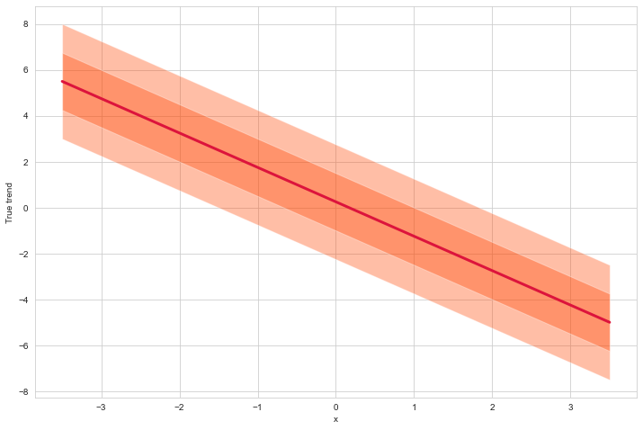

```python
fig, ax = plt.subplots(figsize=(12,8))

ax.plot(df_viz.x, df_viz.trend, color='crimson', linewidth=3)

# variation around the trend
ax.fill_between(df_viz.x, df_viz.lwr_2, df_viz.upr_2, facecolor='orangered', alpha=0.35)
ax.fill_between(df_viz.x, df_viz.lwr_1, df_viz.upr_1, facecolor='orangered', alpha=0.35)

ax.set_xlabel('x')
ax.set_ylabel('True trend')

plt.show()
```

Generate a small set of observations to work with.

```python
rg = np.random.default_rng(2100)
```

```python
df = pd.DataFrame({'x': np.linspace(-3, 3, num=11)})
```

```python
df['trend'] = my_intercept + my_slope * df.x
```

```python
df['y'] = rg.normal(loc = df.trend, scale=my_sigma, size=df.shape[0])
```

```python
df
```

|  | x | trend | y |
| --- | --- | --- | --- |
| 0 | -3.0 | 4.75 | 6.030315 |
| 1 | -2.4 | 3.85 | 1.682911 |
| 2 | -1.8 | 2.95 | 2.838383 |
| 3 | -1.2 | 2.05 | 0.682815 |
| 4 | -0.6 | 1.15 | 1.551244 |
| 5 | 0.0 | 0.25 | -1.129007 |
| 6 | 0.6 | -0.65 | -1.619992 |
| 7 | 1.2 | -1.55 | -1.962097 |
| 8 | 1.8 | -2.45 | -4.263282 |
| 9 | 2.4 | -3.35 | -2.013640 |
| 10 | 3.0 | -4.25 | -4.503014 |

Visualize the randomly generated responses on the ribbons for context.

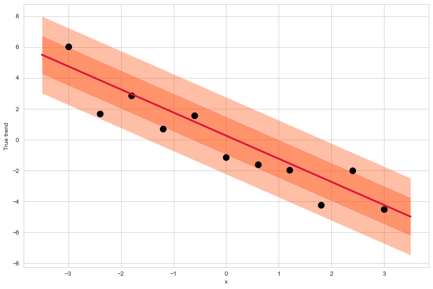

```python
fig, ax = plt.subplots(figsize=(12,8))

# the true trend
ax.plot(df_viz.x, df_viz.trend, color='crimson', linewidth=3)

# variability/uncertainty around the trend
ax.fill_between(df_viz.x, df_viz.lwr_2, df_viz.upr_2, facecolor='orangered', alpha=0.35)
ax.fill_between(df_viz.x, df_viz.lwr_1, df_viz.upr_1, facecolor='orangered', alpha=0.35)

# randomly generated responses
ax.scatter(df.x, df.y, color='k', s=100)

ax.set_xlabel('x')
ax.set_ylabel('True trend')

plt.show()
```

## Graphically fit the model

```python
intercept_values = np.linspace(-3, 3, num=101)
slope_values = np.linspace(-3, 3, num=101)
```

```python
b_grid = pd.DataFrame([(x0, x1) for x0 in intercept_values for x1 in slope_values],
                      columns=['b0', 'b1'])
```

```python
b_grid.info()
```

```
<class 'pandas.core.frame.DataFrame'>
RangeIndex: 10201 entries, 0 to 10200
Data columns (total 2 columns):
 #   Column  Non-Null Count  Dtype
---  ------  --------------  -----
 0   b0      10201 non-null  float64
 1   b1      10201 non-null  float64
dtypes: float64(2)
memory usage: 159.5 KB
```

Define a function to calculate the trend for us.

```python
def calculate_trend_df(b0, b1, x):
    res = pd.DataFrame({'x': x})
    res['trend'] = b0 + b1 * res.x
    res['b0'] = b0
    res['b1'] = b1

    return res
```

Define a function which handles summarizing the error metric for each combination of coefficients.

```python
def summarize_performance(bgrid, data_use, input_name):
    # calculate the trend for each coefficient combination
    trend_list = []
    for ix in bgrid.index:
        trend_list.append(calculate_trend_df(bgrid.iloc[ix].b0,
                                             bgrid.iloc[ix].b1,
                                             data_use[input_name]))

    # concat all dataframes within the list together
    study_df = pd.concat( trend_list ).reset_index(drop=True)

    # rename the input feature from the generic x to whatever input_name is
    study_df.rename(columns={'x': input_name}, inplace=True)

    # merge in the observed response
    study_df = study_df.\
    merge(data_use.loc[:, [input_name, 'y']].copy(), on=[input_name])

    # calculate the squared error
    study_df['squared_error'] = (study_df.y - study_df.trend) ** 2

    # summarize the squared error for each intercept and slope combination
    study_res = study_df.groupby(['b0', 'b1']).\
    aggregate(SSE = ('squared_error', 'sum'),
              MSE = ('squared_error', 'mean')).\
    reset_index()

    # calculate the RMSE
    study_res['RMSE'] = np.sqrt( study_res.MSE )

    return study_res
```

Calculate the RMSE for each intercept and slope combination.

```python
performance_summary = summarize_performance(b_grid, df, 'x')
```

```python
performance_summary.info()
```

```
<class 'pandas.core.frame.DataFrame'>
RangeIndex: 10201 entries, 0 to 10200
Data columns (total 5 columns):
 #   Column  Non-Null Count  Dtype
---  ------  --------------  -----
 0   b0      10201 non-null  float64
 1   b1      10201 non-null  float64
 2   SSE     10201 non-null  float64
 3   MSE     10201 non-null  float64
 4   RMSE    10201 non-null  float64
dtypes: float64(5)
memory usage: 398.6 KB
```

Visualize the RMSE as "surface" by using RMSE as the hue of a scatter plot.

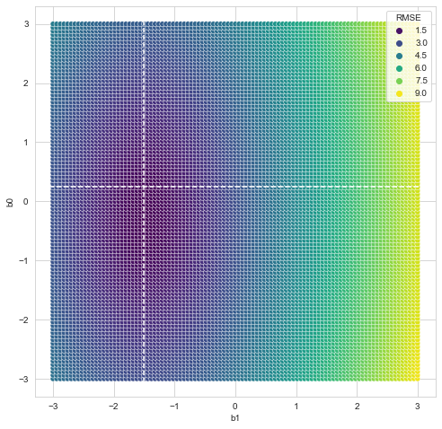

```python
fig, ax = plt.subplots(figsize=(8,8))

sns.scatterplot(data = performance_summary, x='b1', y='b0', hue='RMSE', palette='viridis', ax=ax)

ax.axvline(x = my_slope, color='white', linestyle='--')
ax.axhline(y = my_intercept, color='white', linestyle='--')

plt.show()
```

Binarize the colors, so we mark a region of "low" error from a region of "higher" error.

```python
performance_summary['error_cat'] = np.where( performance_summary.RMSE <= 1.15 * performance_summary.RMSE.min(),
                                           'low',
                                           'high')
```

```python
performance_summary.info()
```

```
<class 'pandas.core.frame.DataFrame'>
RangeIndex: 10201 entries, 0 to 10200
Data columns (total 6 columns):
 #   Column     Non-Null Count  Dtype
---  ------     --------------  -----
 0   b0         10201 non-null  float64
 1   b1         10201 non-null  float64
 2   SSE        10201 non-null  float64
 3   MSE        10201 non-null  float64
 4   RMSE       10201 non-null  float64
 5   error_cat  10201 non-null  object
dtypes: float64(5), object(1)
memory usage: 478.3+ KB
```

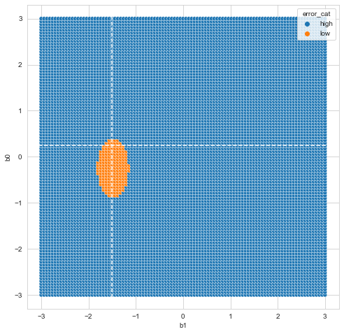

```python
fig, ax = plt.subplots(figsize=(8,8))

sns.scatterplot(data = performance_summary, x='b1', y='b0', hue='error_cat', ax=ax)

ax.axvline(x = my_slope, color='white', linestyle='--')
ax.axhline(y = my_intercept, color='white', linestyle='--')

plt.show()
```

## OLS estimate

```python
import statsmodels.formula.api as smf
```

We will fit a linear model with a linear relationship between the input and the response.

$$ \mathrm{trend}_n = \beta_0 + \beta_1 x_{n} $$

```python
lm_fit = smf.ols(formula= 'y ~ x', data = df).fit()
```

```python
print( lm_fit.summary() )
```

```
                            OLS Regression Results
==============================================================================
Dep. Variable:                      y   R-squared:                       0.862
Model:                            OLS   Adj. R-squared:                  0.846
Method:                 Least Squares   F-statistic:                     56.06
Date:                Thu, 04 Nov 2021   Prob (F-statistic):           3.74e-05
Time:                        19:11:19   Log-Likelihood:                -16.853
No. Observations:                  11   AIC:                             37.71
Df Residuals:                       9   BIC:                             38.50
Df Model:                           1
Covariance Type:            nonrobust
==============================================================================
                 coef    std err          t      P>|t|      [0.025      0.975]
------------------------------------------------------------------------------
Intercept     -0.2459      0.373     -0.659      0.526      -1.090       0.598
x             -1.4730      0.197     -7.487      0.000      -1.918      -1.028
==============================================================================
Omnibus:                        0.814   Durbin-Watson:                   2.822
Prob(Omnibus):                  0.666   Jarque-Bera (JB):                0.676
Skew:                           0.303   Prob(JB):                        0.713
Kurtosis:                       1.948   Cond. No.                         1.90
==============================================================================

Notes:
[1] Standard Errors assume that the covariance matrix of the errors is correctly specified.
```

Extract the coefficient estimates.

```python
lm_fit.params
```

```
Intercept   -0.245942
x           -1.473014
dtype: float64
```

Include the estimates for the coefficients on our graphical solution.

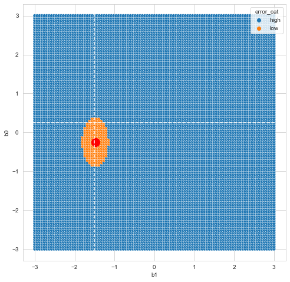

```python
fig, ax = plt.subplots(figsize=(8,8))

sns.scatterplot(data = performance_summary, x='b1', y='b0', hue='error_cat', ax=ax)

ax.axvline(x = my_slope, color='white', linestyle='--')
ax.axhline(y = my_intercept, color='white', linestyle='--')

ax.scatter(lm_fit.params[1], lm_fit.params[0], color='red', s=200)

plt.show()
```

We are uncertain about the coefficients.

```python
lm_fit.bse
```

```
Intercept    0.373274
x            0.196732
dtype: float64
```

```python
fit_coef_info = pd.DataFrame({'estimate': lm_fit.params,
                              'estimate_se': lm_fit.bse})
```

```python
fit_coef_info
```

|  | estimate | estimate_se |
| --- | --- | --- |
| Intercept | -0.245942 | 0.373274 |
| x | -1.473014 | 0.196732 |

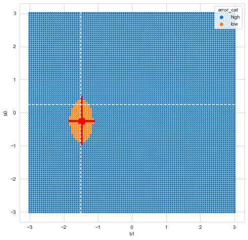

```python
fig, ax = plt.subplots(figsize=(8,8))

sns.scatterplot(data = performance_summary, x='b1', y='b0', hue='error_cat', ax=ax)

ax.axvline(x = my_slope, color='white', linestyle='--')
ax.axhline(y = my_intercept, color='white', linestyle='--')

ax.scatter(lm_fit.params[1], lm_fit.params[0], color='red', s=200)
ax.errorbar(y=fit_coef_info.loc['Intercept'].estimate,
            x=fit_coef_info.loc['x'].estimate,
            yerr = 2 * fit_coef_info.loc['Intercept'].estimate_se,
            xerr = 2 * fit_coef_info.loc['x'].estimate_se,
            fmt='o', color='red', ecolor='red', elinewidth=4, ms=10)

plt.show()
```

Visualize the coefficient estimates and their standard errors.

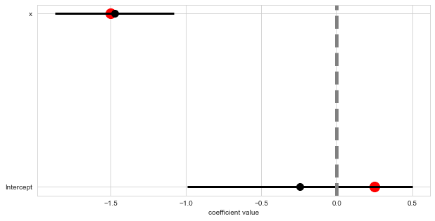

```python
fig, ax = plt.subplots(figsize=(10, 5))

ax.errorbar(y = lm_fit.params.index, x = lm_fit.params,
            xerr = 2 * lm_fit.bse,
            fmt='o', color='k', ecolor='k', elinewidth=3, ms=10)

ax.scatter(y = lm_fit.params.index, x=[my_intercept, my_slope], color='red', s=200)

ax.axvline(x = 0, linestyle='--', linewidth=5, color='grey')

ax.set_xlabel('coefficient value')

plt.show()
```

```python
def my_coefplot(model_object, figsize_use=(10,5)):
    fig, ax = plt.subplots(figsize=figsize_use)

    ax.errorbar(y=model_object.params.index, x=model_object.params,
                xerr = 2 * model_object.bse,
                fmt='o', color='k', ecolor='k', elinewidth=3, ms=10)

    ax.axvline(x=0, linestyle='--', color='grey')

    ax.set_xlabel('coefficient value')

    plt.show()
```

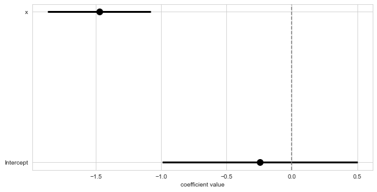

```python
my_coefplot(lm_fit)
```

## Performance

Let's look at the "goodness of fit" of the model.

```python
lm_fit.fittedvalues
```

```
0     4.173099
1     3.289291
2     2.405483
3     1.521674
4     0.637866
5    -0.245942
6    -1.129750
7    -2.013559
8    -2.897367
9    -3.781175
10   -4.664983
dtype: float64
```

```python
df_copy = df.copy()
```

```python
df_copy['fitted'] = lm_fit.fittedvalues
```

```python
df_copy
```

|  | x | trend | y | fitted |
| --- | --- | --- | --- | --- |
| 0 | -3.0 | 4.75 | 6.030315 | 4.173099 |
| 1 | -2.4 | 3.85 | 1.682911 | 3.289291 |
| 2 | -1.8 | 2.95 | 2.838383 | 2.405483 |
| 3 | -1.2 | 2.05 | 0.682815 | 1.521674 |
| 4 | -0.6 | 1.15 | 1.551244 | 0.637866 |
| 5 | 0.0 | 0.25 | -1.129007 | -0.245942 |
| 6 | 0.6 | -0.65 | -1.619992 | -1.129750 |
| 7 | 1.2 | -1.55 | -1.962097 | -2.013559 |
| 8 | 1.8 | -2.45 | -4.263282 | -2.897367 |
| 9 | 2.4 | -3.35 | -2.013640 | -3.781175 |
| 10 | 3.0 | -4.25 | -4.503014 | -4.664983 |

Examine or visualize the training set performance by plotting the model "fits" vs the observed output. This kind of figure is known as the **predicted vs observed** figure.

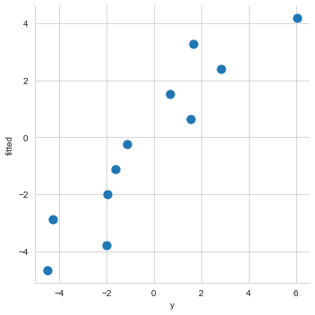

```python
sns.relplot(data = df_copy, x='y', y='fitted', s=125)

plt.show()
```

Include a "45-degree" reference line.

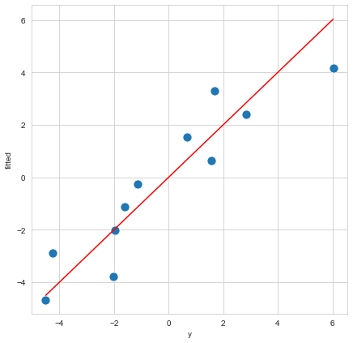

```python
fig, ax = plt.subplots(figsize=(7,7))

sns.scatterplot(data = df_copy, x='y', y='fitted', s=125, ax=ax)

sns.lineplot(data = df_copy, x='y', y='y', color='red', ax=ax)

plt.show()
```

Calculate the correlation coefficient between the observed output and the model fit.

```python
df_copy.loc[:, ['y', 'fitted']].corr()
```

|  | y | fitted |
| --- | --- | --- |
| y | 1.000000 | 0.928261 |
| fitted | 0.928261 | 1.000000 |

```python
df_copy.loc[:, ['y', 'fitted']].corr().iloc[0, 1]
```

```
0.9282610227010393
```

```python
df_copy.loc[:, ['y', 'fitted']].corr().iloc[0, 1] ** 2
```

```
0.8616685262659793
```

```python
lm_fit.rsquared
```

```
0.8616685262659792
```

### Residuals

```python
df_copy['errors'] = df_copy.y - df_copy.fitted
```

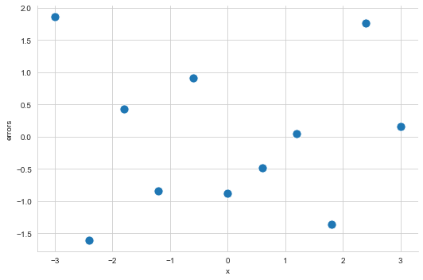

```python
sns.relplot(data = df_copy, x='x', y='errors', s=125, aspect=1.5)

plt.show()
```

```python
lm_fit.resid
```

```
0     1.857216
1    -1.606380
2     0.432900
3    -0.838859
4     0.913378
5    -0.883065
6    -0.490242
7     0.051462
8    -1.365915
9     1.767535
10    0.161969
dtype: float64
```

Visualize the model behavior with statsmodels.

```python
import statsmodels.api as sm
```

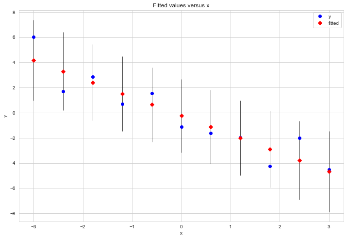

```python
fig, ax = plt.subplots(figsize=(12,8))

sm.graphics.plot_fit(lm_fit, 'x', ax=ax)

plt.show()
```

The model fits, the residuals, and a partial regression plot with respect to a single input.

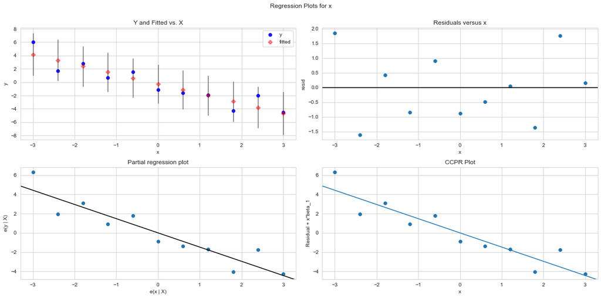

```python
fig = plt.figure(figsize=(16, 8))

sm.graphics.plot_regress_exog(lm_fit, 'x', fig=fig)

plt.show()
```

### Predictions

```python
grid_for_viz = df_viz.copy()
```

```python
grid_for_viz.head()
```

|  | x | trend | lwr_1 | upr_1 | lwr_2 | upr_2 |
| --- | --- | --- | --- | --- | --- | --- |
| 0 | -3.50 | 5.50 | 4.25 | 6.75 | 3.00 | 8.00 |
| 1 | -3.36 | 5.29 | 4.04 | 6.54 | 2.79 | 7.79 |
| 2 | -3.22 | 5.08 | 3.83 | 6.33 | 2.58 | 7.58 |
| 3 | -3.08 | 4.87 | 3.62 | 6.12 | 2.37 | 7.37 |
| 4 | -2.94 | 4.66 | 3.41 | 5.91 | 2.16 | 7.16 |

```python
pred_lm = lm_fit.predict( grid_for_viz )
```

```python
print( type(pred_lm) )
```

```
<class 'pandas.core.series.Series'>
```

```python
grid_for_viz['pred'] = pred_lm
```

```python
grid_for_viz.head()
```

|  | x | trend | lwr_1 | upr_1 | lwr_2 | upr_2 | pred |
| --- | --- | --- | --- | --- | --- | --- | --- |
| 0 | -3.50 | 5.50 | 4.25 | 6.75 | 3.00 | 8.00 | 4.909606 |
| 1 | -3.36 | 5.29 | 4.04 | 6.54 | 2.79 | 7.79 | 4.703384 |
| 2 | -3.22 | 5.08 | 3.83 | 6.33 | 2.58 | 7.58 | 4.497162 |
| 3 | -3.08 | 4.87 | 3.62 | 6.12 | 2.37 | 7.37 | 4.290940 |
| 4 | -2.94 | 4.66 | 3.41 | 5.91 | 2.16 | 7.16 | 4.084718 |

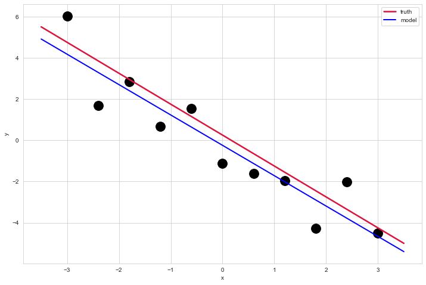

```python
fig, ax = plt.subplots(figsize=(12,8))

ax.plot(grid_for_viz.x, grid_for_viz.trend, color='crimson', linewidth=2.5, label='truth')
ax.plot(grid_for_viz.x, grid_for_viz.pred, color='blue', linewidth=2, label='model')
ax.scatter(df.x, df.y, s=250, color='k')

ax.set_xlabel('x')
ax.set_ylabel('y')

ax.legend()

plt.show()
```

Use a method to extract the **confidence interval** and the **prediction interval**.

```python
predictions = lm_fit.get_prediction( df_viz )
```

```python
viz_summary_lm = predictions.summary_frame(alpha=0.05)
```

```python
viz_summary_lm.head()
```

|  | mean | mean_se | mean_ci_lower | mean_ci_upper | obs_ci_lower | obs_ci_upper |
| --- | --- | --- | --- | --- | --- | --- |
| 0 | 4.909606 | 0.783232 | 3.137811 | 6.681400 | 1.595629 | 8.223583 |
| 1 | 4.703384 | 0.759132 | 2.986108 | 6.420661 | 1.418232 | 7.988536 |
| 2 | 4.497162 | 0.735274 | 2.833857 | 6.160468 | 1.239897 | 7.754427 |
| 3 | 4.290940 | 0.711682 | 2.681003 | 5.900877 | 1.060602 | 7.521278 |
| 4 | 4.084718 | 0.688384 | 2.527486 | 5.641950 | 0.880322 | 7.289115 |

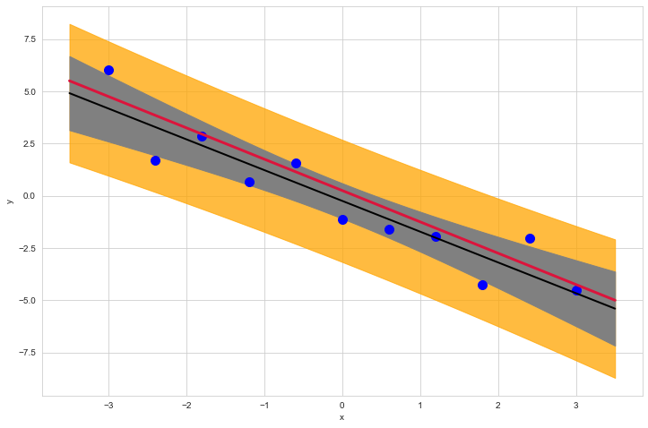

```python
fig, ax = plt.subplots(figsize=(12, 8))

# the truth
ax.plot(df_viz.x, df_viz.trend, color='crimson', linewidth=3)

# prediction interval - uncertainty in the response
ax.fill_between(df_viz.x, viz_summary_lm.obs_ci_lower, viz_summary_lm.obs_ci_upper,
                facecolor='orange', alpha=0.75, edgecolor='orange')

# confidence interval - uncertainty in the average
ax.fill_between(df_viz.x, viz_summary_lm.mean_ci_lower, viz_summary_lm.mean_ci_upper,
                facecolor='grey', alpha=1.0, edgecolor='grey')

# mean trend - the model prediction
ax.plot(df_viz.x, viz_summary_lm['mean'], color='black', linewidth=2)

# observed data - training data
ax.scatter(df.x, df.y, color='blue', s=100)

ax.set_xlabel('x')
ax.set_ylabel('y')

plt.show()
```